# Project on Machine Learning Algorithm

```
         Wine Quality Predictions
```

# PROBLEM STATEMENT:

OBJECTIVE 1: To make use of wine quality data and to create clusters/groups based on similarities between them(Unsupervised learning).

OBJECTIVE 2: To make use of wine quality data and predict the quality of wine(Supervised learning).

# PROBLEM FEATURE:

The datasets contains various features/ columns regarding the content, density, colour etc. of the wine based on which they are grouped into few homogeneous categories by using unsupervised learning ML algorithms. Later on, supervised ML algorithms are used to predict the goodness feature of the wine. Evaluation metrics intended to use in this classificatio problem are as follows. 1) Accuracy 2) F1 Score.

# FEATURE ENGINEERING:

Analysis of data using various plots like scatter,regression bar,etc. to identify trends or patterns between and among dependent and independent variables. Scaling or standardization of feature values for unsupervised learning. One-hot-encoding of categorical columns.

In this JUPYTER NOTEBOOK i have done with the data visualization

```python
#install/import packages libraries


from sklearn.metrics import make_scorer, accuracy_score # for accuracy
from sklearn.model_selection import train_test_split # for splitting the train-test data
from sklearn.ensemble import RandomForestClassifier # random forest model
from sklearn.linear_model import LogisticRegression # regression
from sklearn.linear_model import LinearRegression # regression
from sklearn.metrics import classification_report # to create all accuracy matrices
from sklearn.model_selection import GridSearchCV # hyper parameter optimization
from sklearn.metrics import confusion_matrix # cofusion matrix / accuracy
from sklearn.metrics import accuracy_score # accuracy score / accuracy
from sklearn import preprocessing # EDA
from sklearn.preprocessing import StandardScaler,LabelEncoder
from sklearn import decomposition
import matplotlib.pylab as pylab # visualization
import matplotlib.pyplot as plt # visualization
from pandas import get_dummies # EDA
import matplotlib as mpl  # visualization
import seaborn as sns # visualization
import pandas as pd # EDA
import numpy as np # EDA
import matplotlib # visualization
import warnings # EDA
import sklearn # machine learning
import scipy  # EDA
import json # EDA
import sys # EDA
import csv # EDA
import os # to work with the the work libraries / system related variables
import math
```

```python
# code to see the output of multiple lines of codes

from IPython.core.interactiveshell import InteractiveShell
InteractiveShell.ast_node_interactivity = 'all'
```

WINE QUALITY DATASETS:

Reading Data:---- For reading data from csv file we will be making use of "read_csv".

```python
# LOADING THE FILE USING READ_CSV

wine_quality = pd.read_csv('C:/Users/SONY/Downloads/data science//projectds/winequality.csv')
wine_quality
```

|  | fixed acidity | volatile acidity | citric acid | residual sugar | chlorides | free sulfur dioxide | total sulfur dioxide | density | pH | sulphates | alcohol | quality | good | color |
| --- | --- | --- | --- | --- | --- | --- | --- | --- | --- | --- | --- | --- | --- | --- |
| 0 | 7.4 | 0.70 | 0.00 | 1.9 | 0.076 | 11.0 | 34.0 | 0.99780 | 3.51 | 0.56 | 9.4 | 5 | 0 | red |
| 1 | 7.8 | 0.88 | 0.00 | 2.6 | 0.098 | 25.0 | 67.0 | 0.99680 | 3.20 | 0.68 | 9.8 | 5 | 0 | red |
| 2 | 7.8 | 0.76 | 0.04 | 2.3 | 0.092 | 15.0 | 54.0 | 0.99700 | 3.26 | 0.65 | 9.8 | 5 | 0 | red |
| 3 | 11.2 | 0.28 | 0.56 | 1.9 | 0.075 | 17.0 | 60.0 | 0.99800 | 3.16 | 0.58 | 9.8 | 6 | 0 | red |
| 4 | 7.4 | 0.70 | 0.00 | 1.9 | 0.076 | 11.0 | 34.0 | 0.99780 | 3.51 | 0.56 | 9.4 | 5 | 0 | red |
| ... | ... | ... | ... | ... | ... | ... | ... | ... | ... | ... | ... | ... | ... | ... |
| 6492 | 6.2 | 0.21 | 0.29 | 1.6 | 0.039 | 24.0 | 92.0 | 0.99114 | 3.27 | 0.50 | 11.2 | 6 | 0 | white |
| 6493 | 6.6 | 0.32 | 0.36 | 8.0 | 0.047 | 57.0 | 168.0 | 0.99490 | 3.15 | 0.46 | 9.6 | 5 | 0 | white |
| 6494 | 6.5 | 0.24 | 0.19 | 1.2 | 0.041 | 30.0 | 111.0 | 0.99254 | 2.99 | 0.46 | 9.4 | 6 | 0 | white |
| 6495 | 5.5 | 0.29 | 0.30 | 1.1 | 0.022 | 20.0 | 110.0 | 0.98869 | 3.34 | 0.38 | 12.8 | 7 | 1 | white |
| 6496 | 6.0 | 0.21 | 0.38 | 0.8 | 0.020 | 22.0 | 98.0 | 0.98941 | 3.26 | 0.32 | 11.8 | 6 | 0 | white |

6497 rows × 14 columns

# DATA ANALYSIS ON DATASETS

```python
type(wine_quality)
wine_quality.head()
wine_quality.describe()
wine_quality.info()
print(wine_quality.shape)
wine_quality.columns
```

```
pandas.core.frame.DataFrame
```

|  | fixed acidity | volatile acidity | citric acid | residual sugar | chlorides | free sulfur dioxide | total sulfur dioxide | density | pH | sulphates | alcohol | quality | good | color |
| --- | --- | --- | --- | --- | --- | --- | --- | --- | --- | --- | --- | --- | --- | --- |
| 0 | 7.4 | 0.70 | 0.00 | 1.9 | 0.076 | 11.0 | 34.0 | 0.9978 | 3.51 | 0.56 | 9.4 | 5 | 0 | red |
| 1 | 7.8 | 0.88 | 0.00 | 2.6 | 0.098 | 25.0 | 67.0 | 0.9968 | 3.20 | 0.68 | 9.8 | 5 | 0 | red |
| 2 | 7.8 | 0.76 | 0.04 | 2.3 | 0.092 | 15.0 | 54.0 | 0.9970 | 3.26 | 0.65 | 9.8 | 5 | 0 | red |
| 3 | 11.2 | 0.28 | 0.56 | 1.9 | 0.075 | 17.0 | 60.0 | 0.9980 | 3.16 | 0.58 | 9.8 | 6 | 0 | red |
| 4 | 7.4 | 0.70 | 0.00 | 1.9 | 0.076 | 11.0 | 34.0 | 0.9978 | 3.51 | 0.56 | 9.4 | 5 | 0 | red |

|  | fixed acidity | volatile acidity | citric acid | residual sugar | chlorides | free sulfur dioxide | total sulfur dioxide | density | pH | sulphates | alcohol | quality | good |
| --- | --- | --- | --- | --- | --- | --- | --- | --- | --- | --- | --- | --- | --- |
| count | 6497.000000 | 6497.000000 | 6497.000000 | 6497.000000 | 6497.000000 | 6497.000000 | 6497.000000 | 6497.000000 | 6497.000000 | 6497.000000 | 6497.000000 | 6497.000000 | 6497.000000 |
| mean | 7.215307 | 0.339666 | 0.318633 | 5.443235 | 0.056034 | 30.525319 | 115.744574 | 0.994697 | 3.218501 | 0.531268 | 10.491801 | 5.818378 | 0.196552 |
| std | 1.296434 | 0.164636 | 0.145318 | 4.757804 | 0.035034 | 17.749400 | 56.521855 | 0.002999 | 0.160787 | 0.148806 | 1.192712 | 0.873255 | 0.397421 |
| min | 3.800000 | 0.080000 | 0.000000 | 0.600000 | 0.009000 | 1.000000 | 6.000000 | 0.987110 | 2.720000 | 0.220000 | 8.000000 | 3.000000 | 0.000000 |
| 25% | 6.400000 | 0.230000 | 0.250000 | 1.800000 | 0.038000 | 17.000000 | 77.000000 | 0.992340 | 3.110000 | 0.430000 | 9.500000 | 5.000000 | 0.000000 |
| 50% | 7.000000 | 0.290000 | 0.310000 | 3.000000 | 0.047000 | 29.000000 | 118.000000 | 0.994890 | 3.210000 | 0.510000 | 10.300000 | 6.000000 | 0.000000 |
| 75% | 7.700000 | 0.400000 | 0.390000 | 8.100000 | 0.065000 | 41.000000 | 156.000000 | 0.996990 | 3.320000 | 0.600000 | 11.300000 | 6.000000 | 0.000000 |
| max | 15.900000 | 1.580000 | 1.660000 | 65.800000 | 0.611000 | 289.000000 | 440.000000 | 1.038980 | 4.010000 | 2.000000 | 14.900000 | 9.000000 | 1.000000 |

```
<class 'pandas.core.frame.DataFrame'>
RangeIndex: 6497 entries, 0 to 6496
Data columns (total 14 columns):
fixed acidity           6497 non-null float64
volatile acidity        6497 non-null float64
citric acid             6497 non-null float64
residual sugar          6497 non-null float64
chlorides               6497 non-null float64
free sulfur dioxide     6497 non-null float64
total sulfur dioxide    6497 non-null float64
density                 6497 non-null float64
pH                      6497 non-null float64
sulphates               6497 non-null float64
alcohol                 6497 non-null float64
quality                 6497 non-null int64
good                    6497 non-null int64
color                   6497 non-null object
dtypes: float64(11), int64(2), object(1)
memory usage: 685.3+ KB
(6497, 14)
```

```
Index(['fixed acidity', 'volatile acidity', 'citric acid', 'residual sugar',
       'chlorides', 'free sulfur dioxide', 'total sulfur dioxide', 'density',
       'pH', 'sulphates', 'alcohol', 'quality', 'good', 'color'],
      dtype='object')
```

# MISSING VALUE ON DATA SETS

```python
def check_missing_data(wine_quality):
    flag=wine_quality.isna().sum().any()
    if flag==True:
        total = wine_quality.isnull().sum()
        percent = (wine_quality.isnull().sum())/(wine_quality.isnull().count()*100)
        output = pd.concat([total, percent], axis=1, keys=['Total', 'Percent'])
        data_type = []
        for col in wine_quality.columns:
            dtype = str(wine_quality[col].dtype)
            data_type.append(dtype)
        output['Types'] = data_type
        return(np.transpose(output))
    else:
        return(False)

check_missing_data(wine_quality)

#function for missing data
def missing_value(wine_quality):
    total = wine_quality.isnull().sum().sort_values(ascending=False)
    percent = (wine_quality.isnull().sum()/wine_quality.isnull().count()).sort_values(ascending=False)
    missing_data = pd.concat([total, percent], axis=1, keys=['Total', 'Percent'])
    return(missing_data.head(20))
missing_value(wine_quality)
```

```
False
```

|  | Total | Percent |
| --- | --- | --- |
| color | 0 | 0.0 |
| good | 0 | 0.0 |
| quality | 0 | 0.0 |
| alcohol | 0 | 0.0 |
| sulphates | 0 | 0.0 |
| pH | 0 | 0.0 |
| density | 0 | 0.0 |
| total sulfur dioxide | 0 | 0.0 |
| free sulfur dioxide | 0 | 0.0 |
| chlorides | 0 | 0.0 |
| residual sugar | 0 | 0.0 |
| citric acid | 0 | 0.0 |
| volatile acidity | 0 | 0.0 |
| fixed acidity | 0 | 0.0 |

# SCATTER PLOT

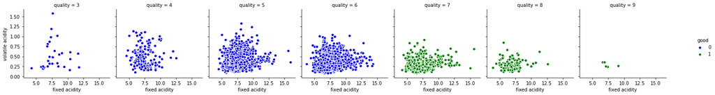

```python
## modify the graph above by aasigning each species an individual color
g=sns.FacetGrid(wine_quality, hue="good", col="quality",margin_titles=True,
                palette={1:"green",0:"blue"})
g=g.map(plt.scatter,"fixed acidity","volatile acidity",edgecolor="w").add_legend();
```

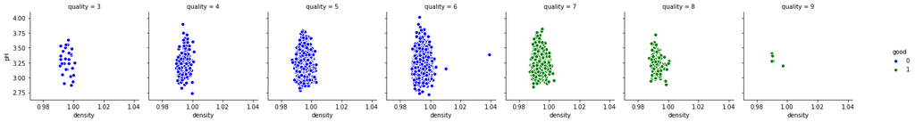

```python
## modify the graph above by aasigning each species an individual color
g=sns.FacetGrid(wine_quality, hue="good", col="quality",margin_titles=True,
                palette={1:"green",0:"blue"})
g=g.map(plt.scatter,"density","pH",edgecolor="w").add_legend();
```

SCATTER PLOT:- DEPENDENT VARIABLE-QUALITY VS ALL INDEPENDENT VARIABLES

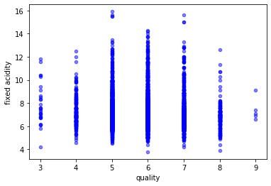

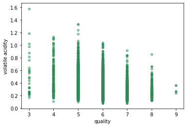

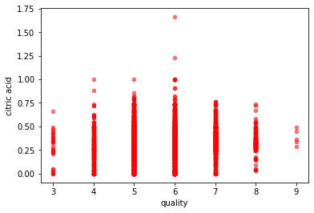

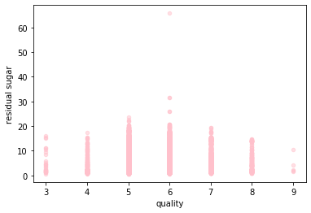

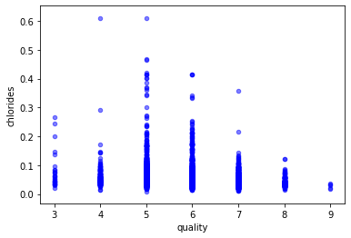

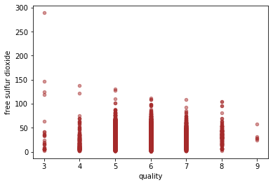

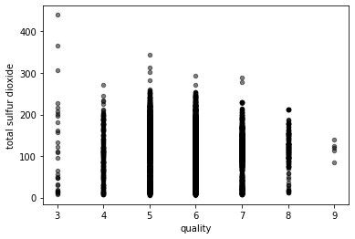

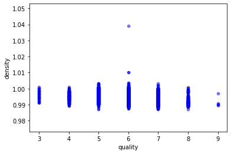

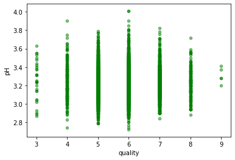

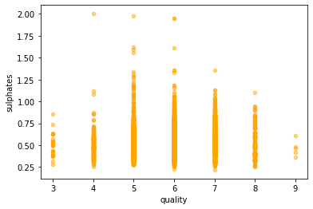

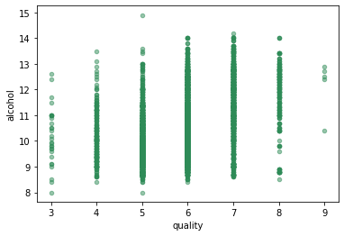

```python
wine_quality.plot(kind="scatter",x="quality",y="fixed acidity",alpha=0.5,color="blue")
wine_quality.plot(kind="scatter",x="quality",y="volatile acidity",alpha=0.5,color="seagreen")
wine_quality.plot(kind="scatter",x="quality",y="citric acid",alpha=0.5,color="red")
wine_quality.plot(kind="scatter",x="quality",y="residual sugar",alpha=0.5,color="pink")
wine_quality.plot(kind="scatter",x="quality",y="chlorides",alpha=0.5,color="blue")
wine_quality.plot(kind="scatter",x="quality",y="free sulfur dioxide",alpha=0.5,color="brown")
wine_quality.plot(kind="scatter",x="quality",y="total sulfur dioxide",alpha=0.5,color="black")
wine_quality.plot(kind="scatter",x="quality",y="density",alpha=0.5,color="blue")
wine_quality.plot(kind="scatter",x="quality",y="pH",alpha=0.5,color="green")
wine_quality.plot(kind="scatter",x="quality",y="sulphates",alpha=0.5,color="orange")
wine_quality.plot(kind="scatter",x="quality",y="alcohol",alpha=0.5,color="seagreen")
```

SCATTER PLOT:- DEPENDENT VARIABLE-GOOD VS ALL INDEPENDENT VARIABLES

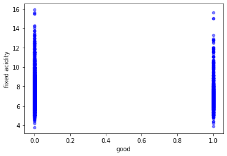

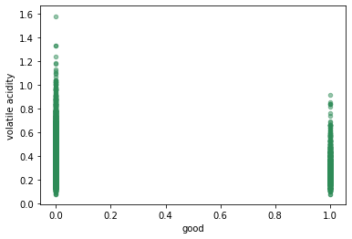

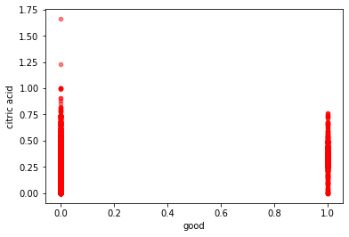

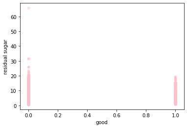

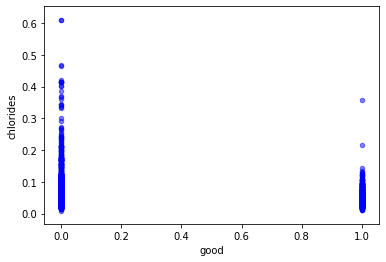

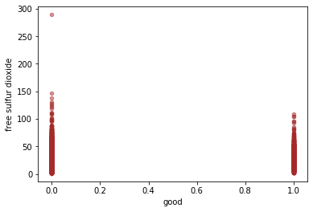

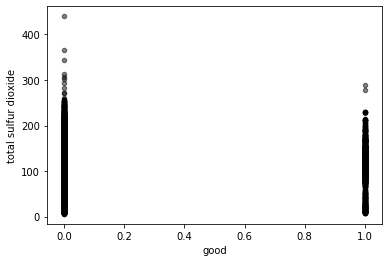

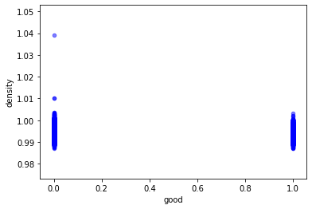

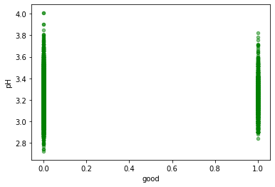

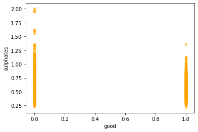

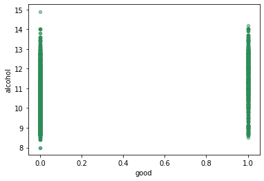

```python
wine_quality.plot(kind="scatter",x="good",y="fixed acidity",alpha=0.5,color="blue")
wine_quality.plot(kind="scatter",x="good",y="volatile acidity",alpha=0.5,color="seagreen")
wine_quality.plot(kind="scatter",x="good",y="citric acid",alpha=0.5,color="red")
wine_quality.plot(kind="scatter",x="good",y="residual sugar",alpha=0.5,color="pink")
wine_quality.plot(kind="scatter",x="good",y="chlorides",alpha=0.5,color="blue")
wine_quality.plot(kind="scatter",x="good",y="free sulfur dioxide",alpha=0.5,color="brown")
wine_quality.plot(kind="scatter",x="good",y="total sulfur dioxide",alpha=0.5,color="black")
wine_quality.plot(kind="scatter",x="good",y="density",alpha=0.5,color="blue")
wine_quality.plot(kind="scatter",x="good",y="pH",alpha=0.5,color="green")
wine_quality.plot(kind="scatter",x="good",y="sulphates",alpha=0.5,color="orange")
wine_quality.plot(kind="scatter",x="good",y="alcohol",alpha=0.5,color="seagreen")
```